# Project: Investigate a Dataset - FBI NICS Firearm Background Check Data

### Step 3: Create a new dataset df3 containing merge of df1 and df2_unpivot

df2_unpivot has demographic data and df1 has the data for the background checks. When merged, these two can contribute to a lot more. Especially for the population metrics

```python
#Explore various demographic facts to isolate interesting ones for further exploration
df2_unpivot['Fact_cleaned'].value_counts()
```

```
Persons under 5 years                                                   100
Persons under 18 years                                                  100
Persons 65 years and over                                               100
Female persons                                                          100
Housing units                                                           100
Population estimates                                                     50
Total retail sales                                                       50
Per capita income in past 12 months                                      50
Median household income                                                  50
Mean travel time to work , workers age 16 years+                         50
Total retail sales per capita                                            50
Total health care and social assistance receipts/revenue                 50
Total merchant wholesaler sales                                          50
Total manufacturers shipments                                            50
Total accommodation and food services sales                              50
In civilian labor force, female,  of population age 16 years+            50
Total employer establishments                                            50
Total employment,  change                                                50
Total employment                                                         50
Total annual payroll                                                     50
With a disability, under age 65 years                                    50
Total nonemployer establishments                                         50
All firms                                                                50
Men-owned firms                                                          50
Women-owned firms                                                        50
Minority-owned firms                                                     50
Nonminority-owned firms                                                  50
Veteran-owned firms                                                      50
Nonveteran-owned firms                                                   50
Population per square mile                                               50
In civilian labor force, total,  of population age 16 years+             50
Language other than English spoken at home,  of persons age 5 years+     50
Bachelor's degree or higher,  of persons age 25 years+                   50
Veterans                                                                 50
Population,  change -   to                                               50
Population, Census                                                       50
White alone                                                              50
Black or African American alone                                          50
American Indian and Alaska Native alone                                  50
Asian alone                                                              50
Native Hawaiian and Other Pacific Islander alone                         50
Two or More Races                                                        50
Hispanic or Latino                                                       50
White alone, not Hispanic or Latino                                      50
Foreign born persons                                                     50
High school graduate or higher,  of persons age 25 years+                50
Owner-occupied housing unit rate                                         50
Median value of owner-occupied housing units                             50
Median selected monthly owner costs -with a mortgage                     50
Median selected monthly owner costs -without a mortgage                  50
Median gross rent                                                        50
Building permits                                                         50
Households                                                               50
Persons per household                                                    50
Living in same house 1 year ago,  of persons age 1 year+                 50
Population estimates base                                                50
Land area in square miles                                                50
Name: Fact_cleaned, dtype: int64
```

```python
#isolate populated metrics from the census data
df2_unpivot_temp = df2_unpivot[df2_unpivot['Fact_cleaned'].isin(
    ['Population per square mile','Population estimates', 'Population estimates base','Persons 65 years and over',
    'Persons under 18 years','Per capita income in past 12 months','High school graduate or higher,  of persons age 25 years+'
    ])].copy()
print('Number of records in original df2 dataset:',len(df2_unpivot))
print('\n Number of records in updated df2 dataset:',len(df2_unpivot_temp))


#isolate the totals and aggregate it by the state and year
df1_summed = df1.groupby(['year','state']).agg(
    total_handgun_checks = ('handgun','sum'),
    total_long_gun_checks = ('long_gun','sum'),
    total_other_checks = ('other','sum'),
    total_permit_checks = ('permit','sum'),
    totals_summed = ('totals','sum'),

).reset_index()
df1_summed.rename(columns={'totals':'totals_summed'},inplace=True)

print('\n Number of records in df1 dataset:',len(df1_summed))

#merge the above created dataframes into 1 final dataframe
df3 = pd.merge(df1_summed,df2_unpivot_temp,left_on=["year","state"], right_on=["Year","State"], how="inner")
print('\n Number of records in df3 merged dataset:',len(df3))
```

```
Number of records in original df2 dataset: 3100

 Number of records in updated df2 dataset: 450

 Number of records in df1 dataset: 1100

 Number of records in df3 merged dataset: 450
```

```python
df3.head()
```

|  | year | state | total_handgun_checks | total_long_gun_checks | total_other_checks | total_permit_checks | totals_summed | Fact | Fact Note | unit | Fact_cleaned | bracket_contents | Extracted_Date_Year | Year | State | Value |
| --- | --- | --- | --- | --- | --- | --- | --- | --- | --- | --- | --- | --- | --- | --- | --- | --- |
| 0 | 2010 | Alabama | 116963.0 | 136519.0 | 1771.0 | 4621.0 | 308607 | Population estimates base, April 1, 2010, (V2... | NaN | NaN | Population estimates base | V2016 | April 1, 2010 | 2010 | Alabama | 4780131.0 |
| 1 | 2010 | Alabama | 116963.0 | 136519.0 | 1771.0 | 4621.0 | 308607 | Persons under 18 years, percent, April 1, 2010 | NaN | percent | Persons under 18 years | NaN | April 1, 2010 | 2010 | Alabama | 23.7 |
| 2 | 2010 | Alabama | 116963.0 | 136519.0 | 1771.0 | 4621.0 | 308607 | Persons 65 years and over, percent, April 1, 2010 | NaN | percent | Persons 65 years and over | NaN | April 1, 2010 | 2010 | Alabama | 13.8 |
| 3 | 2010 | Alabama | 116963.0 | 136519.0 | 1771.0 | 4621.0 | 308607 | Population per square mile, 2010 | NaN | NaN | Population per square mile | NaN | 2010 | 2010 | Alabama | 94.4 |
| 4 | 2010 | Alaska | 25720.0 | 33177.0 | 825.0 | 0.0 | 65909 | Population estimates base, April 1, 2010, (V2... | NaN | NaN | Population estimates base | V2016 | April 1, 2010 | 2010 | Alaska | 710249.0 |

```python
df3.info()
```

```
<class 'pandas.core.frame.DataFrame'>
Int64Index: 450 entries, 0 to 449
Data columns (total 16 columns):
 #   Column                 Non-Null Count  Dtype
---  ------                 --------------  -----
 0   year                   450 non-null    int64
 1   state                  450 non-null    object
 2   total_handgun_checks   450 non-null    float64
 3   total_long_gun_checks  450 non-null    float64
 4   total_other_checks     450 non-null    float64
 5   total_permit_checks    450 non-null    float64
 6   totals_summed          450 non-null    int64
 7   Fact                   450 non-null    object
 8   Fact Note              0 non-null      object
 9   unit                   288 non-null    object
 10  Fact_cleaned           450 non-null    object
 11  bracket_contents       250 non-null    object
 12  Extracted_Date_Year    450 non-null    object
 13  Year                   450 non-null    int64
 14  State                  450 non-null    object
 15  Value                  450 non-null    float64
dtypes: float64(5), int64(3), object(8)
memory usage: 59.8+ KB
```

```python
#check for any duplicates
df3[df3.duplicated()]
```

|  | year | state | total_handgun_checks | total_long_gun_checks | total_other_checks | total_permit_checks | totals_summed | Fact | Fact Note | unit | Fact_cleaned | bracket_contents | Extracted_Date_Year | Year | State | Value |
| --- | --- | --- | --- | --- | --- | --- | --- | --- | --- | --- | --- | --- | --- | --- | --- | --- |

## Exploratory Data Analysis

### Q1 : What are the overall trends in the total background checks over time?

```python
#explore the totals column statistics
df1.totals.describe()
```

```
count     12485.000000
mean      21595.725911
std       32591.418387
min           0.000000
25%        4638.000000
50%       12399.000000
75%       25453.000000
max      541978.000000
Name: totals, dtype: float64
```

```python
#isolate the totals with the maximum value
df1[df1['totals']==541978]

#this looks like the totals value was driven up due to the high number of permit checks - explore later in depth
```

|  | month | state | permit | permit_recheck | handgun | long_gun | other | multiple | admin | prepawn_handgun | prepawn_long_gun | prepawn_other | redemption_handgun | redemption_long_gun | redemption_other | returned_handgun | returned_long_gun | returned_other | rentals_handgun | rentals_long_gun | private_sale_handgun | private_sale_long_gun | private_sale_other | return_to_seller_handgun | return_to_seller_long_gun | return_to_seller_other | totals | month_act | month_name | … |
| --- | --- | --- | --- | --- | --- | --- | --- | --- | --- | --- | --- | --- | --- | --- | --- | --- | --- | --- | --- | --- | --- | --- | --- | --- | --- | --- | --- | --- | --- | --- |
| 2345 | 2014-03-01 | North Carolina | 522188.0 | 0.0 | 1054.0 | 13571.0 | 528.0 | 227 | 0.0 | 3.0 | 16.0 | 2.0 | 1658.0 | 2728.0 | 3.0 | 0.0 | 0.0 | 0.0 | 0.0 | 0.0 | 0.0 | 0.0 | 0.0 | 0.0 | 0.0 | 0.0 | 541978 | 3 | March | … |

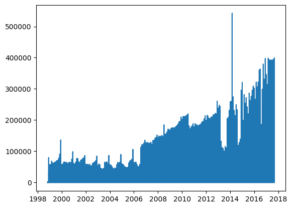

```python
# Plot the totals by yeaar&month
plt.plot(df1.month, df1.totals)
```

##### The number of background checks conducted shows a steady increase with time, with a peak seen around 2014. it is seen that the peak in 2014 is caused due to an increase in the number of permit requests in the state of North Carolina

### Q2 : Single out the trends in the state of North Carolina and explore the trend in permits in this state

As seen as a part of exploration Q#1, NC state had the highest totals value caused due to the permits driving the number up. Hence, explore this in detail

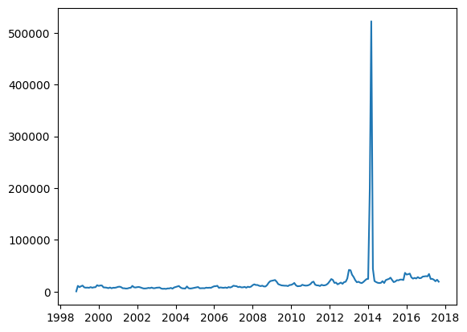

```python
#plot the trend of the permit checks for state of north carolina, similar to above.
temp = df1[df1['state']=='North Carolina']
plt.plot(temp.month, temp.permit)
```

##### The above graph shows that the number of background checks initiated for a permit purchase or transfer is usually pretty stable. Something in early 2014 triggered a high number of checks.

#### Explore the population estimates for north carolina state by looking at the change in population between 2010 and 2016. if the percentage change was high, it could help explaian the unusually high number of permit checks.

```python
new = df2_unpivot[(df2_unpivot['State']=='North Carolina') &
            (df2_unpivot['Year']==2016) &
            (df2_unpivot['Fact_cleaned']== 'Population estimates')]['Value'].item()

old = df2_unpivot[(df2_unpivot['State']=='North Carolina') &
            (df2_unpivot['Year']==2010) &
            (df2_unpivot['Fact_cleaned']== 'Population, Census')]['Value'].item()


Population_change = ((new - old)/old)

Previous_pct_change = df2_unpivot[(df2_unpivot['State']=='North Carolina') &
            (df2_unpivot['Year']==2010) &
            (df2_unpivot['Fact_cleaned'].str.contains('change'))]['Value'].item()


if Population_change > Previous_pct_change:
    print('The percentage change in population is more in 2016 compared to what was seen in 2010 by ',Population_change - Previous_pct_change)

elif Population_change == Previous_pct_change:
    print('The percentage change in population is the same in both 2016 and 2010.')
else:
    print('The percentage change in population is more in 2010 compared to what is seen in 2016 by ',Previous_pct_change - Population_change)
```

```
The percentage change in population is more in 2016 compared to what was seen in 2010 by  0.00010844631572412555
```

##### The population percentage change in 2016 in NC specifically, is not too drastic and hence is unable to explain the sudden spike seen in permit requests 2014

#### Explore the housing units for north carolina state by looking at the change in number of units between 2010 and 2016. if the percentage change was high, it could help explaian the unusually high number of permit checks.

```python
#check housing units
df2_unpivot[(df2_unpivot['State']=='North Carolina') & (df2_unpivot['Fact_cleaned']=='Housing units')]

new = df2_unpivot[(df2_unpivot['State']=='North Carolina') &
            (df2_unpivot['Year']==2016) &
            (df2_unpivot['Fact_cleaned']== 'Housing units')]['Value'].item()

old = df2_unpivot[(df2_unpivot['State']=='North Carolina') &
            (df2_unpivot['Year']==2010) &
            (df2_unpivot['Fact_cleaned']== 'Housing units')]['Value'].item()


housing_change = ((new - old)/old)

if housing_change >= 0:
    print('The housing units increased in 2016, compared to 2010 by ',round(housing_change*100,2), '%')
else:
    print('The housing units decreased in 2016, compared to 2010 by ',round(housing_change*100,2), '%')
```

```
The housing units increased in 2016, compared to 2010 by  4.92 %
```

##### The housing units didn't increase drastically in 2016. The number is less than 5% and hence not as significant. So, the high number of permits cannot be attributed to a higher number of houses

##### Based on the census data available, it is difficult to determine the reason behind the sudden jump in the number of permit checks in the state of north carolina in early 2014.

### Q3: Which states have the highest and the lowest total background check? (Top and bottom 10)

```python
#Isolate the top 10 states with lowest background checks
min_checks = df1.groupby('state')['totals'].min().sort_values(ascending=True).head(10).reset_index()
min_checks
```

|  | state | totals |
| --- | --- | --- |
| 0 | Virgin Islands | 0 |
| 1 | Guam | 0 |
| 2 | District of Columbia | 0 |
| 3 | Mariana Islands | 0 |
| 4 | Puerto Rico | 2 |
| 5 | South Carolina | 6 |
| 6 | Pennsylvania | 17 |
| 7 | Illinois | 22 |
| 8 | Virginia | 24 |
| 9 | Hawaii | 28 |

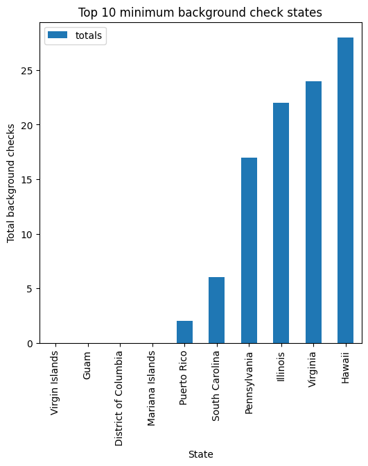

```python
#Visualize the top 10 minimum checks
min_checks.plot(kind='bar',
         x='state',
         y='totals',
         figsize=(6,6),
         title = "Top 10 minimum background check states",
        xlabel="State",
        ylabel="Total background checks")
```

```python
#Isolate the top 10 states with highest background checks
max_checks = df1.groupby('state')['totals'].max().sort_values(ascending=False).head(10).reset_index()
max_checks
```

|  | state | totals |
| --- | --- | --- |
| 0 | North Carolina | 541978 |
| 1 | Kentucky | 398706 |
| 2 | California | 298161 |
| 3 | Texas | 241791 |
| 4 | Indiana | 230892 |
| 5 | Illinois | 189400 |
| 6 | Florida | 168935 |
| 7 | Utah | 156415 |
| 8 | Pennsylvania | 153826 |
| 9 | Washington | 126000 |

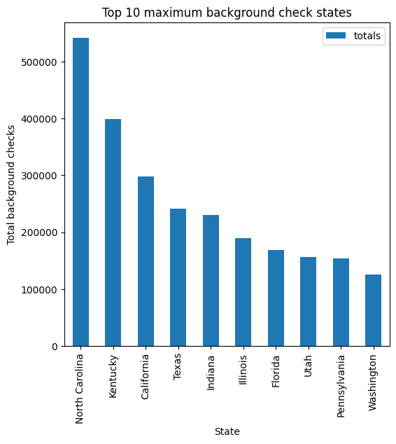

```python
#Visualize the top 10 maximum checks
max_checks.plot(kind='bar',
         x='state',
         y='totals',
         figsize=(6,6),
         title = "Top 10 maximum background check states",
        xlabel="State",
        ylabel="Total background checks")
```

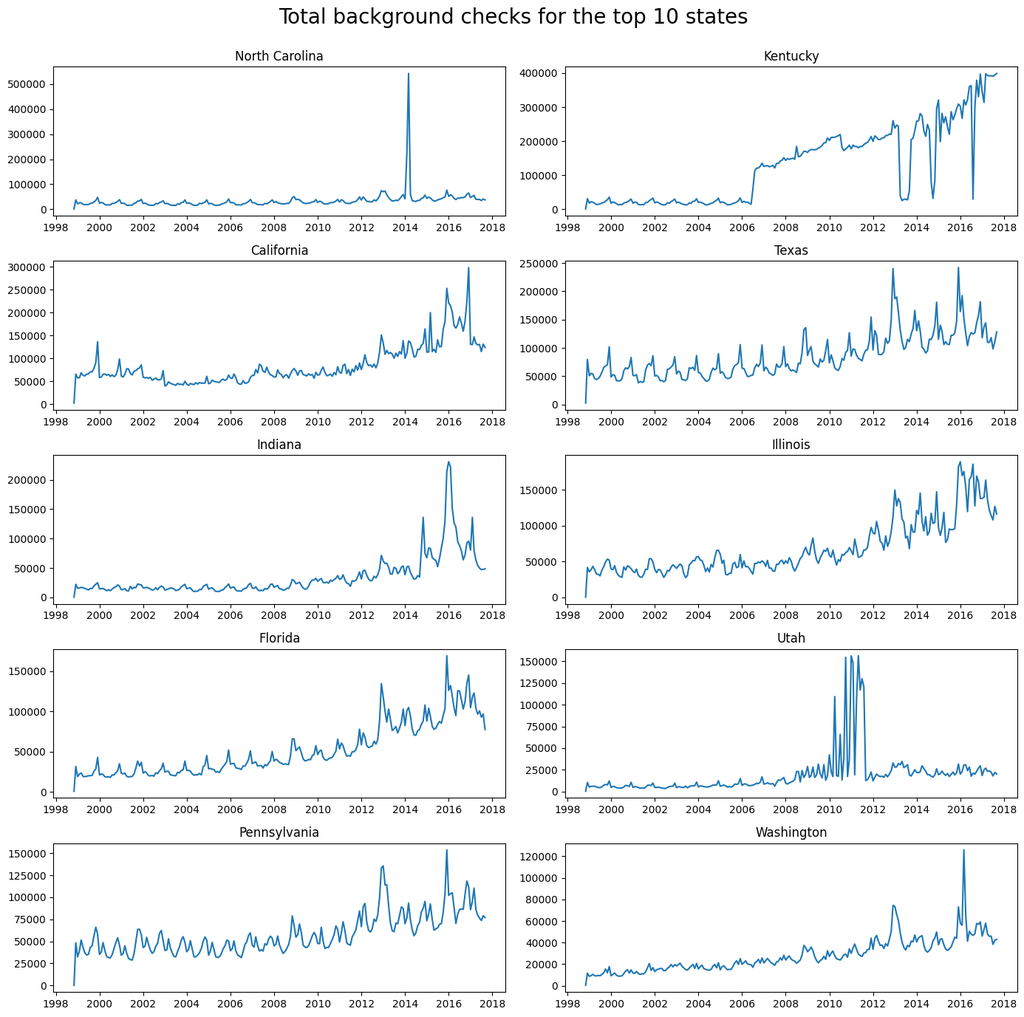

```python
#plot the trend of background checks across all the states through the time period available to identify if
#more cases like north carolina exist.

#create a list of top 10 state names
max_states = max_checks['state'].to_list()

#initialize the plots for the 10 states
fig, axes = plt.subplots(nrows=5, ncols=2, figsize=(14,14),sharex=False, sharey=False)
axes = axes.flatten()

#initialize a counter for the plots
i=0

#plot the line chart
for state in max_states:

    ax=axes[i]
    temp2 = df1[df1['state']==state]
    ax.plot(temp2.month, temp2.totals)
    ax.set_title(state)

    i +=1

fig.suptitle('Total background checks for the top 10 states', fontsize=20)

plt.tight_layout(rect=[0, 0, 1, 0.98])

plt.show()
```

##### The number for NC state can be driven up by the sudden spike in the permit background check as seen in Q1.

##### A lot of the states show sudden increases in the number of checks, namely: North Carolina, Kentucky, Indiana, Utah and Washington.

### Q4: Are there specific months or seasons that show a significant increase or decrease in totals background checks?

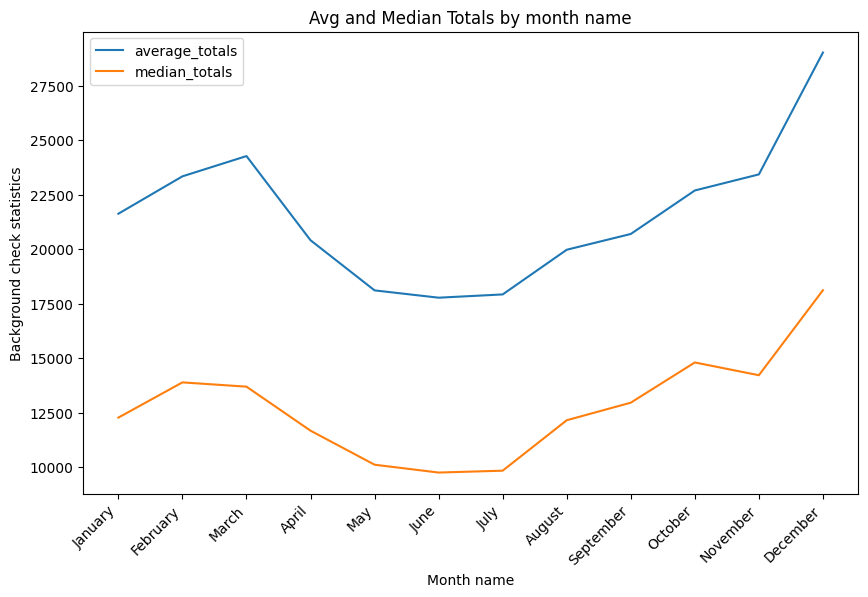

```python
#aggregate the data by month and the mean and median of total background checks
temp = df1.groupby(['month_act', 'month_name'])['totals'].agg(
    average_totals = 'mean',
    median_totals = 'median'
).reset_index()

#sort by month name
temp = temp.sort_values('month_act')

mth_names = temp['month_name'].to_list()
tick_positions = range(len(mth_names))

#create a line chart to show the seasonality
ax = temp.plot(kind='line',
         x='month_name',
         y=['average_totals','median_totals'],
         figsize=(10,6),
         title = "Avg and Median Totals by month name",
        xlabel="Month name",
        ylabel="Background check statistics")

_=ax.set_xticks(tick_positions)
_=ax.set_xticklabels(mth_names, rotation=45, ha='right') # 'ha='right'' helps align rotated labels nicely
```

The mean and median both show the same trend where the number of total background checks for firearms has an increasing trend in the first half of the year, drops from April to July and then again starts showing an increasing trend.

##### The months of November/ December shows a significant uptick in the number of background checks. This is right around the time of Thanksgiving and Christmas in US.

##### Summer months (June/ July) show a quieter period.

#### Exploring the states further to see if this trend exists on a state-level as well

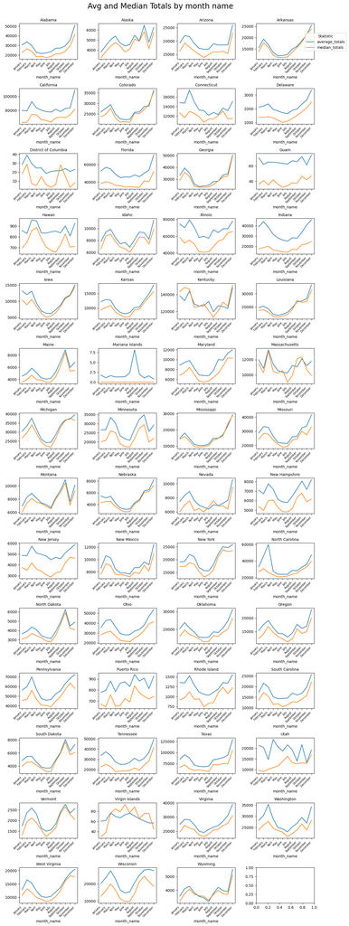

```python
#create a unique list of all the US states
states_list = df1['state'].unique()
len(states_list)

#initialize the plot
fig, axes = plt.subplots(nrows=14, ncols=4, figsize=(12,35),sharex=False, sharey=False)
axes = axes.flatten()


#create a groupby separately to create a summary for each state and month
temp = df1.groupby(['state','month_act', 'month_name'])['totals'].agg(
    average_totals = 'mean',
    median_totals = 'median'
    ).reset_index()

#for each of the state, plot a line chart to showcase the seasonality trend
for i,curr_state in enumerate(states_list):

    ax=axes[i]

    state_data = temp[temp['state']==curr_state]
    state_data = state_data.sort_values('month_act')

    mth_names = state_data['month_name'].to_list()
    tick_positions = range(len(mth_names))


    state_data.plot(kind='line',
             x='month_name',
             y=['average_totals','median_totals'],
            ax=ax, legend=False)

    ax.set_title(curr_state, fontsize=10)

    _=ax.set_xticks(tick_positions)
    _=ax.set_xticklabels(mth_names, rotation=45, ha='right', fontsize=7) # 'ha='right'' helps align rotated labels nicely


# Add a single legend for the entire figure
if len(states_list) > 0:
    handles, labels = axes[0].get_legend_handles_labels()
    fig.legend(handles, labels, loc='upper right', bbox_to_anchor=(1.08, 0.95), title='Statistic', fontsize=10)


fig.suptitle('Avg and Median Totals by month name', fontsize=20)

plt.tight_layout(rect=[0, 0, 1, 0.98]) # Adjust rect to leave space for suptitle

plt.show()
```

##### Almost all states show a high value in the month of December. However, there are also exceptions where the below states also show a high value in the first quarter of the year, in addition to the last month of the year.

- Over 2000 - Connecticut, Illinois, Indiana, Iowa, Kentucky, Massachusetts, Michigan, Minnesota, New Hampshire, New Jersey, North Carolina, Pennsylvania, Utah, Vermont, Washington, wisconsin
- Below 2000 - DC, Guam, Hawaii, Puerto Rico, Rhode Island, Virgin Islands, Mariana Islands

### Q5: Is there a correlation between a state's population and the number of totals background checks?

```python
#Isolate df3 data for the 2016 period only
print("Number of records for year 2016:",len(df3[(df3['year']==2016) & (df3['Fact_cleaned']=='Population estimates')]))
df3_2016 = df3[(df3['year']==2016) & (df3['Fact_cleaned']=='Population estimates')].copy()
df3_2016.shape
```

```
Number of records for year 2016: 50
```

```
(50, 16)
```

```python
df3_2016.head()
```

|  | year | state | total_handgun_checks | total_long_gun_checks | total_other_checks | total_permit_checks | totals_summed | Fact | Fact Note | unit | Fact_cleaned | bracket_contents | Extracted_Date_Year | Year | State | Value |
| --- | --- | --- | --- | --- | --- | --- | --- | --- | --- | --- | --- | --- | --- | --- | --- | --- |
| 100 | 2016 | Alabama | 153123.0 | 121963.0 | 6104.0 | 291039.0 | 616947 | Population estimates, July 1, 2016, (V2016) | NaN | NaN | Population estimates | V2016 | July 1, 2016 | 2016 | Alabama | 4863300.0 |
| 101 | 2016 | Alaska | 37491.0 | 36887.0 | 2889.0 | 3121.0 | 87647 | Population estimates, July 1, 2016, (V2016) | NaN | NaN | Population estimates | V2016 | July 1, 2016 | 2016 | Alaska | 741894.0 |
| 102 | 2016 | Arizona | 166784.0 | 108988.0 | 13122.0 | 87771.0 | 416279 | Population estimates, July 1, 2016, (V2016) | NaN | NaN | Population estimates | V2016 | July 1, 2016 | 2016 | Arizona | 6931071.0 |
| 103 | 2016 | Arkansas | 80244.0 | 82120.0 | 3059.0 | 55456.0 | 266014 | Population estimates, July 1, 2016, (V2016) | NaN | NaN | Population estimates | V2016 | July 1, 2016 | 2016 | Arkansas | 2988248.0 |
| 104 | 2016 | California | 560355.0 | 554550.0 | 211707.0 | 1036981.0 | 2377167 | Population estimates, July 1, 2016, (V2016) | NaN | NaN | Population estimates | V2016 | July 1, 2016 | 2016 | California | 39250017.0 |

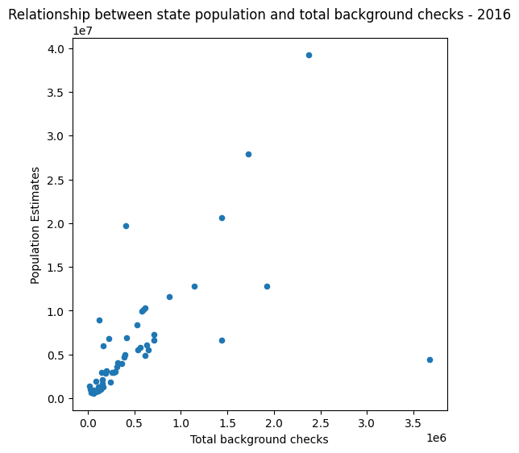

```python
#create a scatter plot to analyze the relationship between total background checks and population estimate
df3_2016.plot(kind='scatter',
         x='totals_summed',
         y='Value',
         figsize=(6,6),
         title = "Relationship between state population and total background checks - 2016",
        xlabel="Total background checks",
        ylabel="Population Estimates")
```

##### The plot above doesn't show a clear relation between the population estimate and the total number of background checks. It seems that the majority of the states have a low population and a low background check since majority concentration is around (0,0)

##### The graph above suggests presence of outliers. For example, California, New York, etc would have a significantly high population compared to Wyoming or other less populous states. Hence, using a log scale might improve the resutls by making it more comparable and meaningful

```
(1000, 4815465.01835708)
```

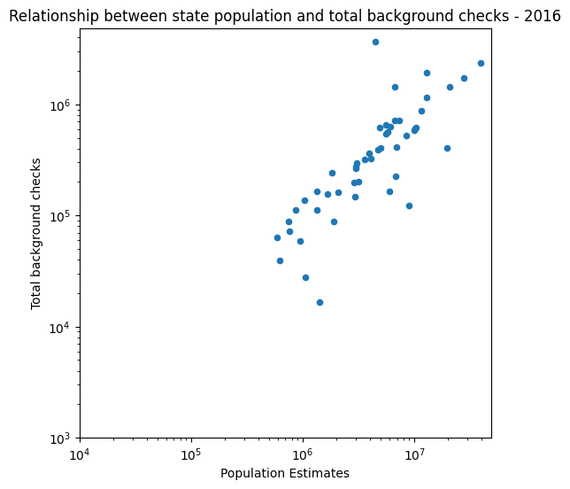

```python
#create a scatter plot to analyze the relationship between total background checks and population estimate on a
#logarithmic scale

ax = df3_2016.plot(kind='scatter',
         x='Value',
         y='totals_summed',
         figsize=(6,6),
         title = "Relationship between state population and total background checks - 2016",
        xlabel="Population Estimates",
        ylabel="Total background checks")

# Set log scales for both axes as recommended for such data
ax.set_xscale('log')
ax.set_yscale('log')
ax.set_xlim(10000,None)
ax.set_ylim(1000,None)
```

##### The logarithmic scale shows a clear increasing trend. As the population estimates increases, the number of background checks conducted also increases

### Q6: Are there any observable relationships between specific demographic facts from the US_Census_Data and the types of firearms being checked in different states?

```python
#check value counts for each of the category of demographic information
df3[['Fact_cleaned','year']].value_counts()
```

```
Fact_cleaned                                               year
High school graduate or higher,  of persons age 25 years+  2015    50
Per capita income in past 12 months                        2015    50
Persons 65 years and over                                  2010    50
                                                           2016    50
Persons under 18 years                                     2010    50
                                                           2016    50
Population estimates                                       2016    50
Population estimates base                                  2010    50
Population per square mile                                 2010    50
dtype: int64
```

```python
#clean the dataframe to have only the most recent data in cases where there could be data from 2010
df3_recent = df3[(df3['year']>=2015) | (df3['Fact_cleaned']=='Population per square mile')].copy()
df3_recent[['Fact_cleaned','year']].value_counts()
```

```
Fact_cleaned                                               year
High school graduate or higher,  of persons age 25 years+  2015    50
Per capita income in past 12 months                        2015    50
Persons 65 years and over                                  2016    50
Persons under 18 years                                     2016    50
Population estimates                                       2016    50
Population per square mile                                 2010    50
dtype: int64
```

```python
#separate and pivot the dataset to calculate the correlation

#isolate firearns data
firearm_check = ['state','year', 'total_handgun_checks', 'total_long_gun_checks',
    'total_other_checks', 'total_permit_checks', 'totals_summed']
df3_firearms = df3_recent[firearm_check].drop_duplicates(subset=['state','year']).reset_index()

#isolate the demographic information and then pivot it
df3_demographics = df3_recent[['state','year' ,'Fact_cleaned', 'Value']].pivot_table(
    index=['state','year'], columns='Fact_cleaned', values='Value'
).reset_index()
df3_demographics.columns.name = None

#combine the two datasets to perform correlation analysis
df_analysis = pd.merge(df3_demographics, df3_firearms, on=['state','year'], how='inner')
df_analysis.head()
```

|  | state | year | High school graduate or higher, of persons age 25 years+ | Per capita income in past 12 months | Persons 65 years and over | Persons under 18 years | Population estimates | Population per square mile | index | total_handgun_checks | total_long_gun_checks | total_other_checks | total_permit_checks | totals_summed |
| --- | --- | --- | --- | --- | --- | --- | --- | --- | --- | --- | --- | --- | --- | --- |
| 0 | Alabama | 2010 | NaN | NaN | NaN | NaN | NaN | 94.4 | 3 | 116963.0 | 136519.0 | 1771.0 | 4621.0 | 308607 |
| 1 | Alabama | 2015 | 84.3 | 24091.0 | NaN | NaN | NaN | NaN | 200 | 243734.0 | 176075.0 | 9442.0 | 246203.0 | 737509 |
| 2 | Alabama | 2016 | NaN | NaN | 16.1 | 22.6 | 4863300.0 | NaN | 300 | 153123.0 | 121963.0 | 6104.0 | 291039.0 | 616947 |
| 3 | Alaska | 2010 | NaN | NaN | NaN | NaN | NaN | 1.2 | 7 | 25720.0 | 33177.0 | 825.0 | 0.0 | 65909 |
| 4 | Alaska | 2015 | 92.1 | 33413.0 | NaN | NaN | NaN | NaN | 202 | 37086.0 | 36372.0 | 2318.0 | 2682.0 | 85621 |

```python
# Define the demographic facts and firearm check types we want to correlate
demographic_facts = [col for col in df_analysis.columns if col not in firearm_check and col != 'state' and col!='year' and col!='index']
firearm_types = [col for col in firearm_check if col != 'state' and col!='year']

# Store correlation results in a list of dictionaries.
correlation_results = []

#calculate pearson correlation coefficient for each demographic fact and firearm type pair
for fact in demographic_facts:
    for type in firearm_types:
        correlation = df_analysis[fact].corr(df_analysis[type])
        correlation_results.append({
            'Fact': fact,
            'Firearm Type': type,
            'Correlation Coefficient': correlation
        })

#store the results from the correlation in a dataframe for visualizing
df_corr = pd.DataFrame(correlation_results)
df_corr.head()
```

|  | Fact | Firearm Type | Correlation Coefficient |
| --- | --- | --- | --- |
| 0 | High school graduate or higher, of persons ag... | total_handgun_checks | -0.094373 |
| 1 | High school graduate or higher, of persons ag... | total_long_gun_checks | -0.077456 |
| 2 | High school graduate or higher, of persons ag... | total_other_checks | 0.070785 |
| 3 | High school graduate or higher, of persons ag... | total_permit_checks | 0.100246 |
| 4 | High school graduate or higher, of persons ag... | totals_summed | 0.041265 |

```python
# pivot the correlation results to create a heatmap
df_heatmap = df_corr.pivot(
    index='Fact',
    columns='Firearm Type',
    values='Correlation Coefficient'
)

df_heatmap.head()
```

| Firearm Type Fact | total_handgun_checks | total_long_gun_checks | total_other_checks | total_permit_checks | totals_summed |
| --- | --- | --- | --- | --- | --- |
| High school graduate or higher, of persons age 25 years+ | -0.094373 | -0.077456 | 0.070785 | 0.100246 | 0.041265 |
| Per capita income in past 12 months | -0.103227 | -0.159563 | -0.044573 | -0.155093 | -0.198390 |
| Persons 65 years and over | -0.075058 | -0.081261 | 0.048333 | 0.109377 | 0.055870 |
| Persons under 18 years | -0.045280 | -0.002695 | 0.097506 | 0.143192 | 0.108065 |
| Population estimates | 0.782618 | 0.911555 | 0.787263 | 0.267508 | 0.605044 |

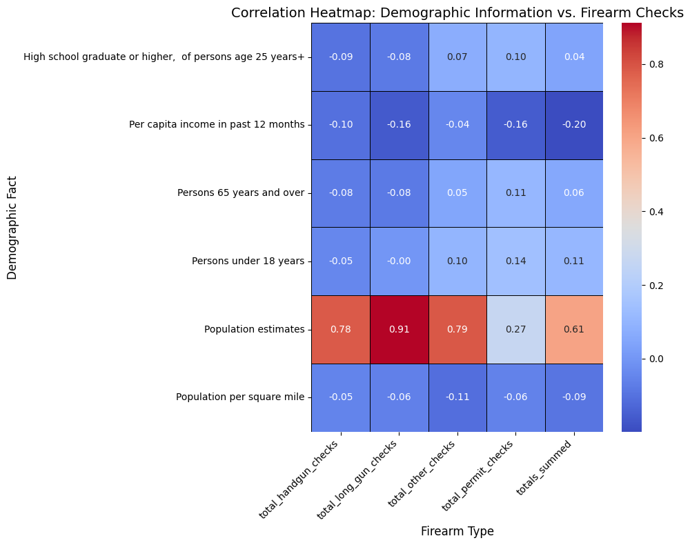

```python
# Create the heatmap
plt.figure(figsize=(10, 8))

sns.heatmap(df_heatmap,
            annot=True,
            cmap='coolwarm',
            fmt=".2f",
            linewidths=.5,
            linecolor='black'
           )

plt.title('Correlation Heatmap: Demographic Information vs. Firearm Checks', fontsize=14)
plt.xlabel('Firearm Type', fontsize=12)
plt.ylabel('Demographic Fact', fontsize=12)
plt.xticks(rotation=45, ha='right')
plt.yticks(rotation=0)
plt.tight_layout()
plt.show()
```

##### Of the 6 demographic information checked, only the Population estimates have a strong correlation with 4 of the 5 background checks. None of the other demographics show a significant correlation with the firearm background check.

##### This goes to show that the Population estimates is a significant factor in the number of background checks conducted.

## Conclusions

### 1. Overall Trends

Through the years, the total number of firearm background checks does not always show a steady increasing trends for all the states. There are sudden spikes in the number at random time periods, unique to each of the states.

### 4. Correlation analysis

A correlation analysis was performed across 6 major demographic factors and corresponding totals for the various types of firearms checked. This revealed that the 'Population estiamte' demographic information has a strong positive correaltion with 4 out of 5 types of firearm background checks, namely - Handgun checks, Long gun checks, Other checks and Total checks. This strongly indicates that the overall population size within an area is a key contributing factor to the volume of background checks conducted.

## Limitations

While the analysis successfully identified the permit spike and ruled out population and housing changes as causes, it could not pinpoint the actual reason behind this anomaly.This suggests that the census dataset used lacks crucial information, such as state-specific policy changes, socio-economic factors, or significant events that might have influenced firearm purchasing and permitting trends during that period.

```python
# Running this cell will execute a bash command to convert this notebook to an .html file
!python -m nbconvert --to html Investigate_a_Dataset.ipynb
```

```
[NbConvertApp] Converting notebook Investigate_a_Dataset.ipynb to html
[NbConvertApp] WARNING | Alternative text is missing on 10 image(s).
[NbConvertApp] Writing 2531756 bytes to Investigate_a_Dataset.html
```